# Presentación Estadística Aplicada III

Alonso Martinez Cisneros

Juan Carlos Sigler Priego

Carlos Delgado

Esmeralda Altamirano

2022-06-06

# Propuesta del Proyecto

# Planteamiento del problema

- Transporte público en la Ciudad de México.
- 9,275,467 habitantes
- ¿Bien planeado y accesible?

## Objetivos

- Cuantificar el nivel de acceso de la población de distintas alcaldías a los diversios medios de transporte público:
  - Metro
  - Metrobus
  - Tren Ligero
  - Cablebus
- Determinar que tan bien distribuido está el transporte público en la ciudad

## Hipótesis

- El transporte público está muy centralizado en la zona del centro histórico.
  - Benito Juárez, Cuauhtémoc son zonas privilegiadas.

# Análisis exploratorio

- Hay 16 alcaldías.
- Años: 1969-2021

| AÑO | ALCALDIA | POBLACION | MEAN_DIST | EST_TOTAL | ZOC_DIST |
| --- | --- | --- | --- | --- | --- |
| 1969 | Azcapotzalco | 527857 | 2019.0774 | 0 | 2028.311 |
| 1970 | Azcapotzalco | 534554 | 1050.1630 | 0 | 2028.311 |
| 1971 | Azcapotzalco | 541251 | 1050.1630 | 0 | 2028.311 |
| 1972 | Azcapotzalco | 547948 | 958.8664 | 0 | 2028.311 |
| 1973 | Azcapotzalco | 554645 | 958.8664 | 0 | 2028.311 |
| 1974 | Azcapotzalco | 561342 | 958.8664 | 0 | 2028.311 |

|  | AÑO | ALCALDIA | POBLACION | MEAN_DIST | EST_TOTAL | ZOC_DIST |
| --- | --- | --- | --- | --- | --- | --- |
|  | Min. :1969 | Length:848 | Min. : 30700 | Min. : 140.8 | Min. : 0.00 | Min. : 2028 |
|  | 1st Qu.:1982 | Class :character | 1st Qu.: 257079 | 1st Qu.: 382.5 | 1st Qu.: 0.00 | 1st Qu.: 3641 |
|  | Median :1995 | Mode :character | Median : 443768 | Median : 942.3 | Median : 5.00 | Median : 5831 |
|  | Mean :1995 | NA | Mean : 532742 | Mean : 2252.4 | Mean : 10.94 | Mean : 7366 |
|  | 3rd Qu.:2008 | NA | 3rd Qu.: 639251 | 3rd Qu.: 3051.8 | 3rd Qu.: 15.00 | 3rd Qu.:12048 |
|  | Max. :2021 | NA | Max. :1840000 | Max. :12926.4 | Max. :118.00 | Max. :17697 |
|  | NA | NA | NA | NA’s :53 | NA | NA’s :53 |

## Descripción de las variables de interés

- `AÑO`
- `ALCALDIA`
- `POBLACIÓN`
- `MEAN_DIST`
- `EST_TOTAL`
- `ZOC_DIST`

## Construcción de la base de datos

### Número total de estaciones por delegación

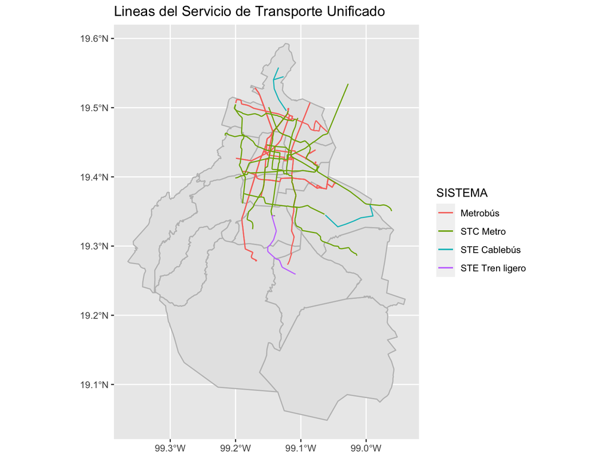

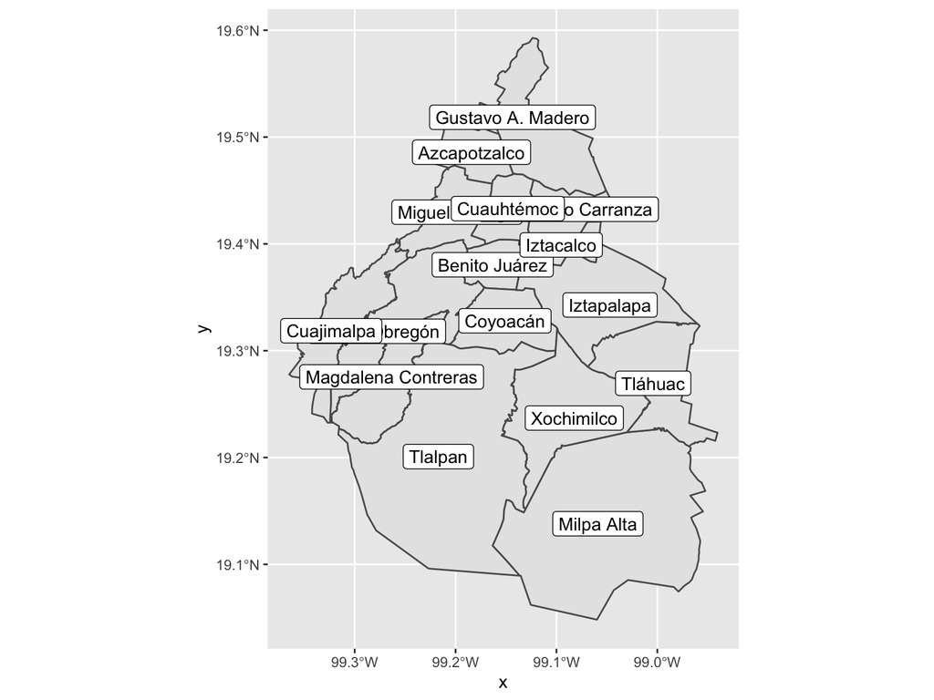

- A simple vista se podría sospechar que el transporte público está concentrado al centro y norte del territorio.
  - Centro: Miguel Hidalgo, Cuauhtémoc, Benito Juárez
- Las carencias más grandes se pueden ver en las alcaldías de Tlalpan, Magdalena Contreras, Xochimilco y Milpa Alta.

### Distancia promedio al transporte público

- `MEAN_DIST`
- Cómo es que el transporte está distribuido con respecto a la *población* y dónde vive ésta.
- Ideas insuficientes
  - Cantidad de estaciones en total contenidas dentro de los límites de una alcaldía
  - Número total de estaciones normalizado por área las alcaldías
- Conectividad: distancia promedio por alcaldía de las zonas residenciales al transporte más cercano.
- Uso de suelo de la CDMX publicado por la Secretaría de Desarrollo Urbano y Vivienda.
  - Falta Álvaro Obregón, una de las más pobladas

### Número total de estaciones & distancia a la zona centro

- Total de estaciones dentro de la alcaldía por año para tomar en cuenta cómo ha evolucionado el sistema de transporte unificado.
- La distancia a la zona centro se toma como la distancia promedio de las mismas zonas residenciales al zócalo de la ciudad.
  - Zócalo como punto central puesto que es una de las zonas más antiguas y por lo tanto el crecimiento de la zona metropolitana de la ciudad ha sido radialmente hacia afuera de esta zona.
  - Las primeras estaciones de metro y metrobus fueron construidas precisamente para servir a la zona centro.

## Acceso a transporte con base en la población

- Concentración alta de transporte en la zona centro.
- Sin embargo, las alcaldías del centro **no** son las más pobladas.

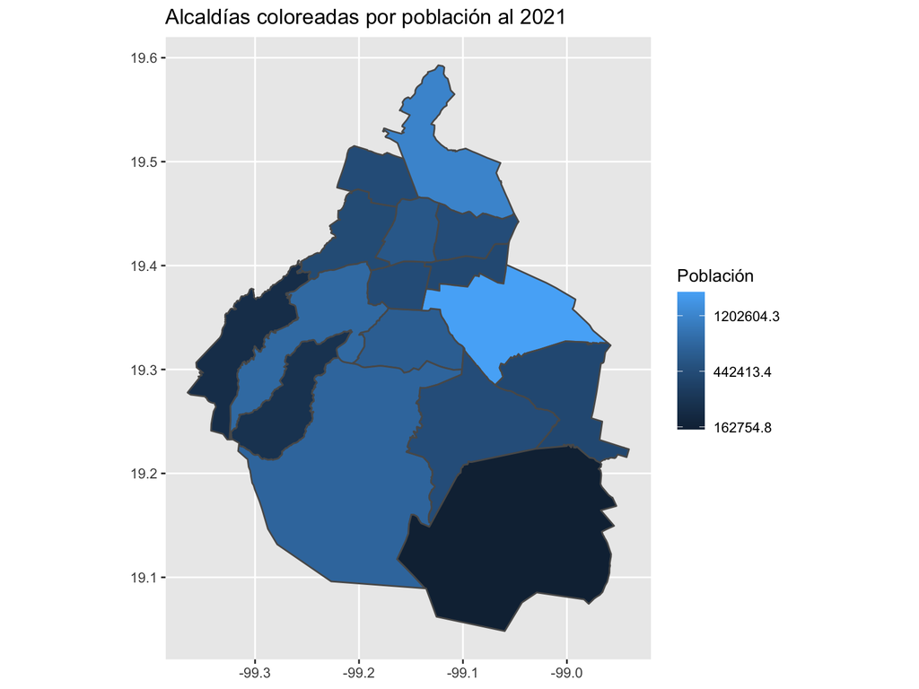

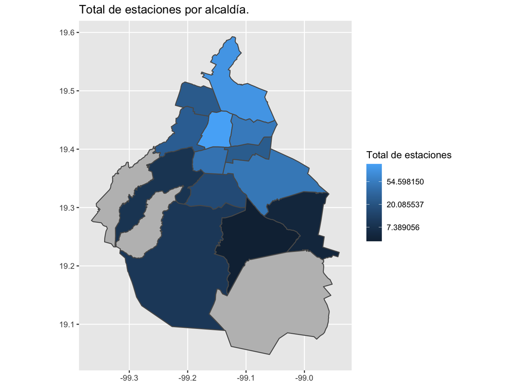

### Evolución de la conectividad como función del tiempo

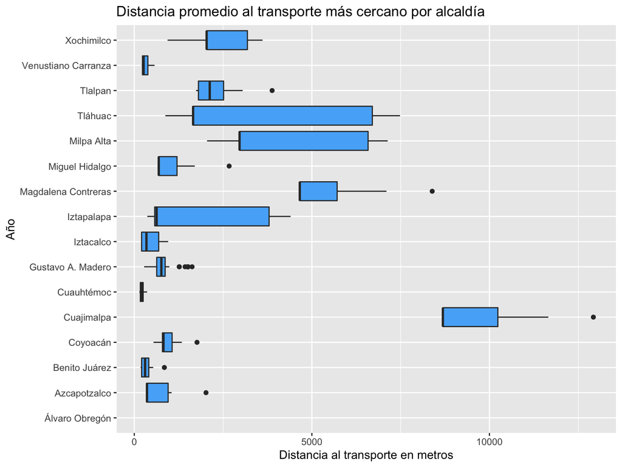

### Total de estaciones por alcaldía a través del tiempo

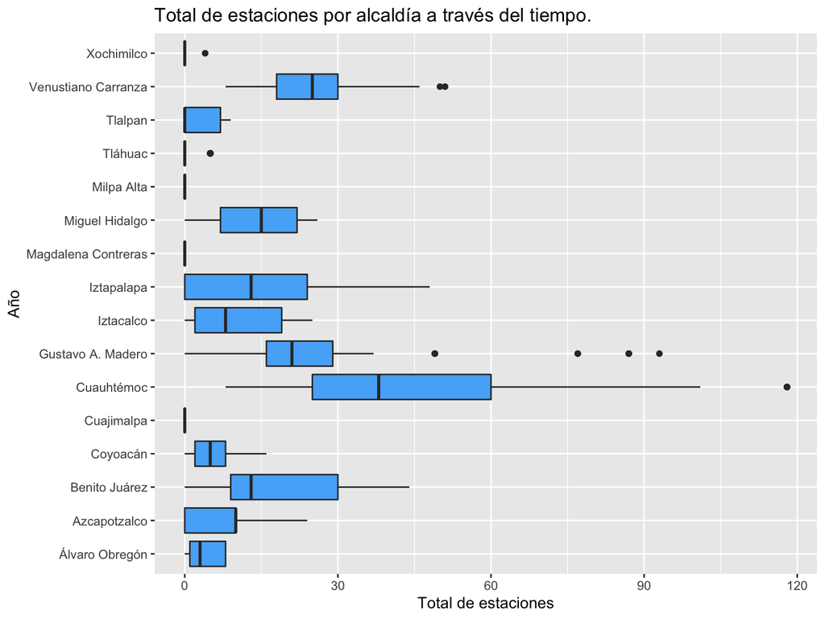

- El número de estaciones en las alcadías de la zona centro excede vastamente el de las alcaldías más periféricas
- Caso Cuauhtémoc y Benito Juárez: privilegiando a la zona centro.

### Análisis de Correlación

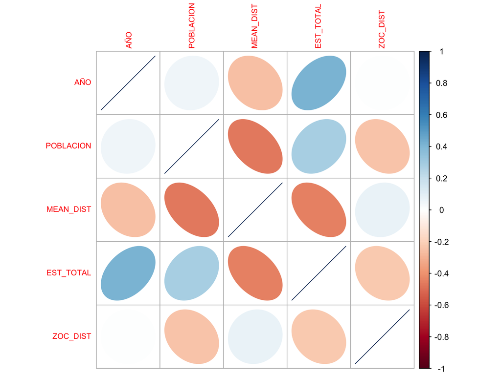

- La correlación de distancia al Zocalo con distancia al transporte más cercano es positiva
- Correlación negativa entre distancia al zócalo con el número total de estaciones.
- Correlaciones son aparentemente débiles, pero notables.

### Matriz explícita de correlaciones

|  | AÑO | POBLACION | MEAN_DIST | EST_TOTAL | ZOC_DIST |
| --- | --- | --- | --- | --- | --- |
| AÑO | 1.0000000 | 0.0502763 | -0.2532690 | 0.4107378 | 0.0000000 |
| POBLACION | 0.0502763 | 1.0000000 | -0.4607899 | 0.2897473 | -0.2489191 |
| MEAN_DIST | -0.2532690 | -0.4607899 | 1.0000000 | -0.4426642 | 0.0766026 |
| EST_TOTAL | 0.4107378 | 0.2897473 | -0.4426642 | 1.0000000 | -0.2217675 |
| ZOC_DIST | 0.0000000 | -0.2489191 | 0.0766026 | -0.2217675 | 1.0000000 |

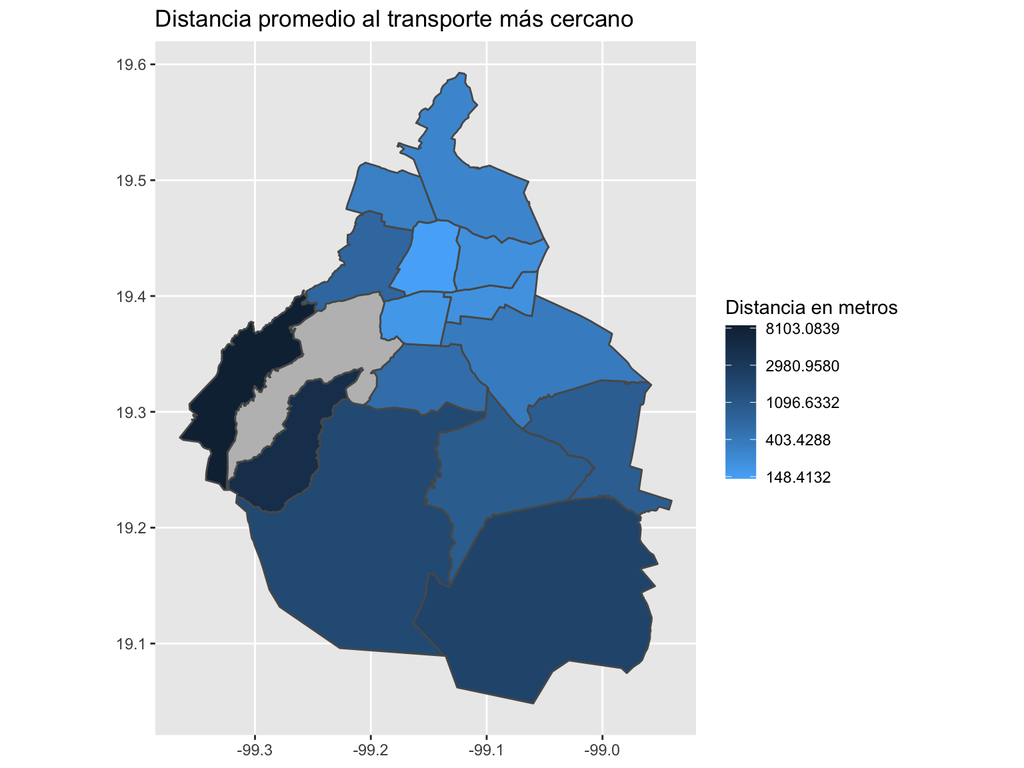

- Correlación visual entre la distancia al transporte más cercano y la distancia al zócalo.

# PCA

```
## Importance of components:
##                          Comp.1    Comp.2    Comp.3    Comp.4     Comp.5
## Standard deviation     1.434476 1.0505992 0.9382218 0.7185053 0.66483939
## Proportion of Variance 0.411544 0.2207517 0.1760520 0.1032500 0.08840228
## Cumulative Proportion  0.411544 0.6322957 0.8083478 0.9115977 1.00000000
##
## Loadings:
##           Comp.1 Comp.2 Comp.3 Comp.4 Comp.5
## AÑO        0.363  0.643  0.327  0.581  0.105
## POBLACION  0.462 -0.434 -0.400  0.496 -0.438
## MEAN_DIST -0.536         0.450  0.239 -0.672
## EST_TOTAL  0.547  0.195  0.231 -0.597 -0.503
## ZOC_DIST  -0.262  0.599 -0.691        -0.303
```

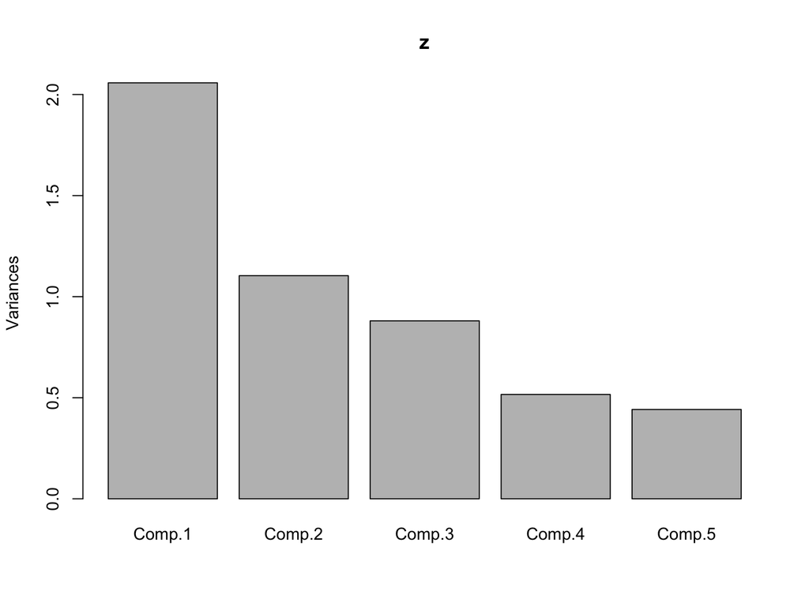

```r
screeplot(z)
```

# Construcción de un índice de conectividad

- Año: 2021
- Análisis factorial
  - Distancia promedio a las estaciones
  - Cantidad de estaciones en la alcaldía

## Pruebas de significancia

```
##
##  Bartlett test of homogeneity of variances
##
## data:  df2
## Bartlett's K-squared = 94.484, df = 1, p-value < 2.2e-16
```

- Kaiser–Meyer–Olkin (KMO)
  - Adecuación medianamente regular

```
## Kaiser-Meyer-Olkin factor adequacy
## Call: KMO(r = cor(df2))
## Overall MSA =  0.5
## MSA for each item =
## EST_TOTAL MEAN_DIST
##       0.5       0.5
```

### Gráfico de sedimentación (scree plot)

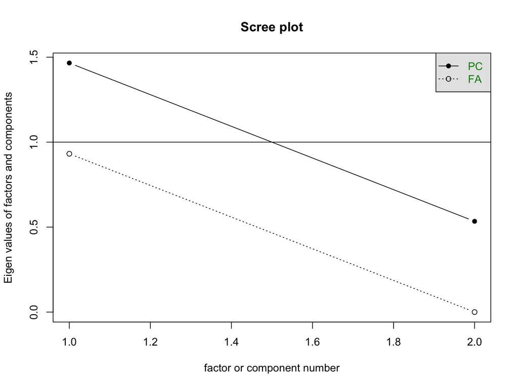

- Un factor es suficiente

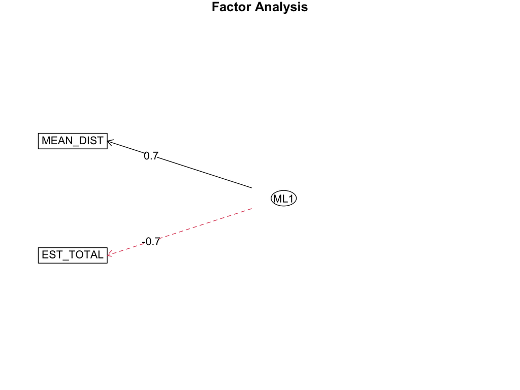

### Índice de conectividad 2021

|  | ML1 |
| --- | --- |
| Cuauhtémoc | 1.0000000 |
| Gustavo A. Madero | 0.8907132 |
| Venustiano Carranza | 0.7253886 |
| Iztapalapa | 0.7035597 |
| Benito Juárez | 0.6990018 |
| Iztacalco | 0.6207869 |
| Azcapotzalco | 0.6093896 |
| Miguel Hidalgo | 0.5969240 |
| Coyoacán | 0.5637512 |
| Tláhuac | 0.4989385 |
| Xochimilco | 0.4910410 |
| Tlalpan | 0.4621720 |
| Milpa Alta | 0.4067971 |
| Magdalena Contreras | 0.2468354 |
| Cuajimalpa | 0.0000000 |

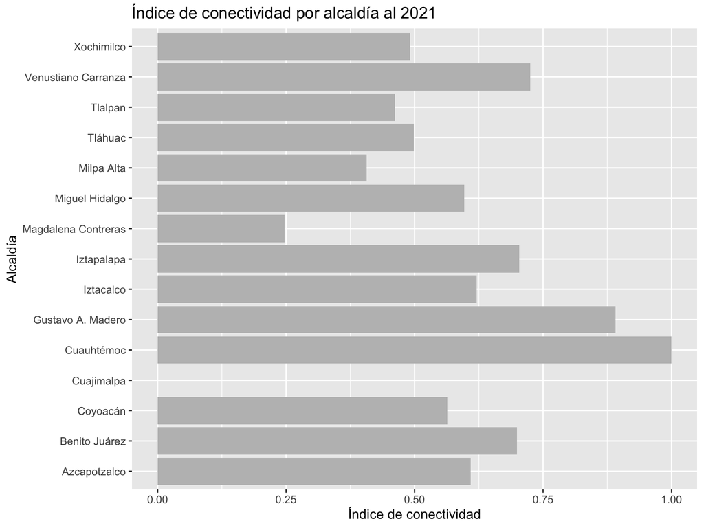

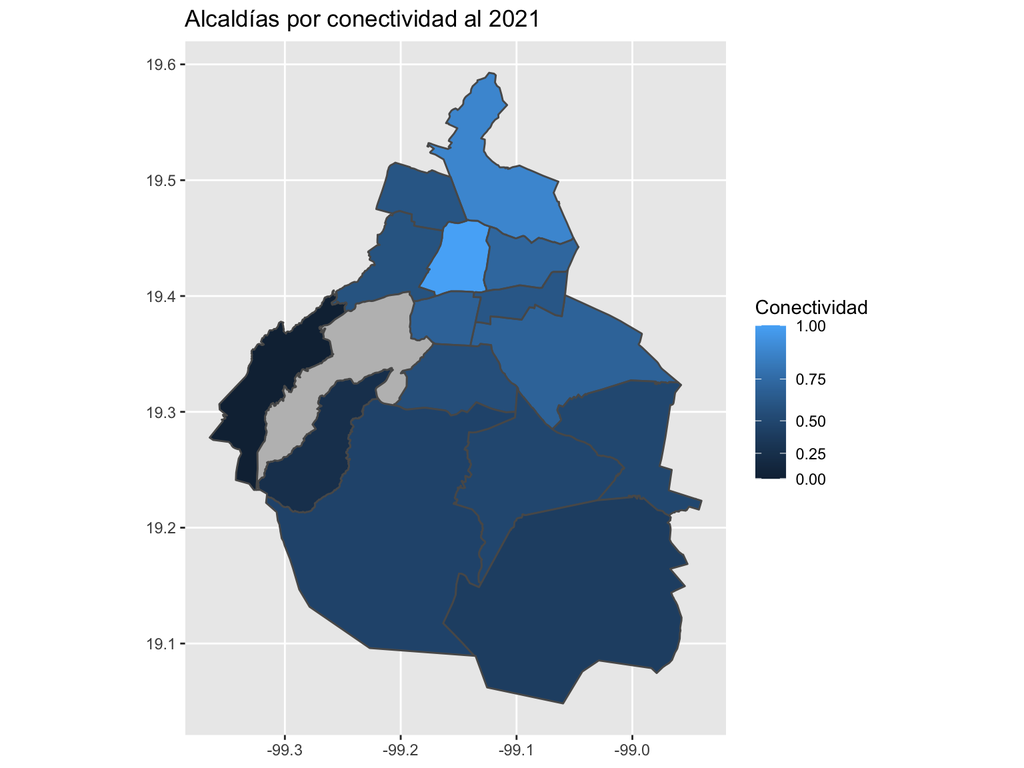

## Análisis del índice de conectividad por año

- ¿Cómo ha evolucionado el índice de conectividad de las diversas alcaldías a medida que ha ido creciendo el sistema de transporte unificado?

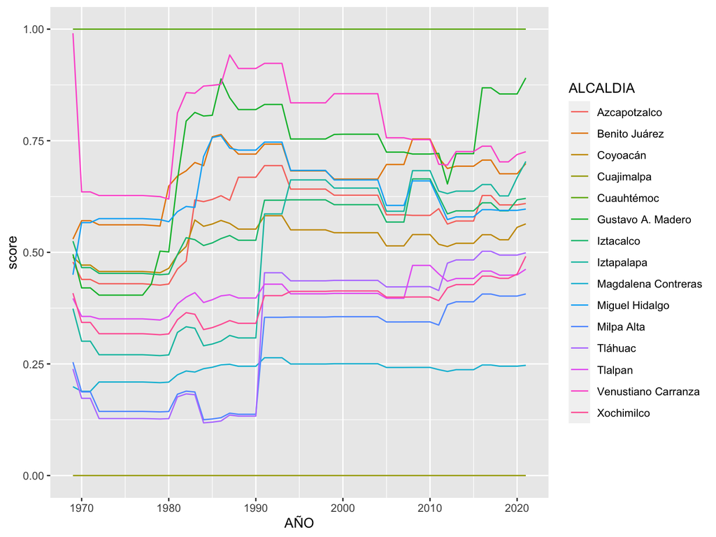

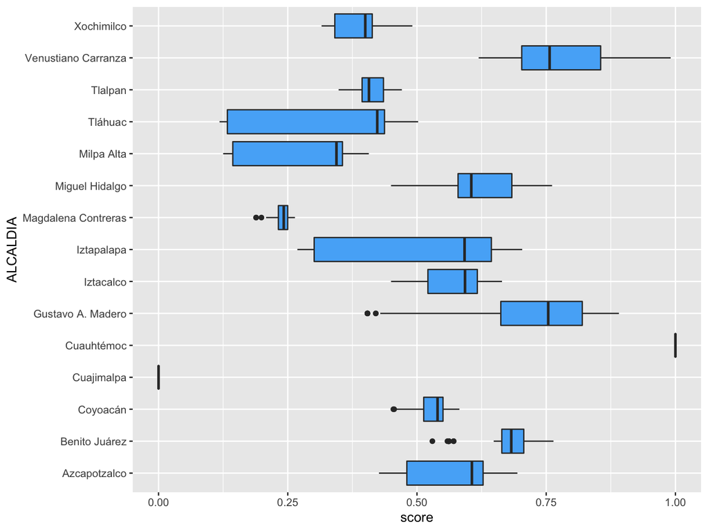

# Regresión lineal

| ALCALDIA | term | estimate | std.error | p.value | is.signif |
| --- | --- | --- | --- | --- | --- |
| Azcapotzalco | (Intercept) | 4.8395077 | 14.8481336 | 0.7458347 | no signif |
| Azcapotzalco | log(AÑO) | -0.3351358 | 1.8724283 | 0.8586731 | no signif |
| Azcapotzalco | log(POBLACION) | -0.2986604 | 0.1099291 | 0.0090293 | signif |
| Benito Juárez | (Intercept) | -1.1798205 | 5.6142127 | 0.8344055 | no signif |
| Benito Juárez | log(AÑO) | 0.3285344 | 0.7222071 | 0.6511478 | no signif |
| Benito Juárez | log(POBLACION) | -0.1317711 | 0.0269835 | 0.0000111 | signif |
| Coyoacán | (Intercept) | -3.0276547 | 3.2105384 | 0.3501968 | no signif |
| Coyoacán | log(AÑO) | 0.3758517 | 0.4325615 | 0.3890549 | no signif |
| Coyoacán | log(POBLACION) | 0.0932374 | 0.0192561 | 0.0000128 | signif |
| Gustavo A. Madero | (Intercept) | -88.9727170 | 13.5027332 | 0.0000000 | signif |
| Gustavo A. Madero | log(AÑO) | 11.3780919 | 1.6680822 | 0.0000000 | signif |
| Gustavo A. Madero | log(POBLACION) | 0.4262438 | 0.1658457 | 0.0131926 | signif |
| Iztacalco | (Intercept) | -9.4734884 | 5.9691397 | 0.1187997 | no signif |
| Iztacalco | log(AÑO) | 1.4785948 | 0.7538061 | 0.0554001 | signif |
| Iztacalco | log(POBLACION) | -0.2160740 | 0.0453903 | 0.0000169 | signif |
| Iztapalapa | (Intercept) | -95.9340396 | 15.1736290 | 0.0000001 | signif |
| Iztapalapa | log(AÑO) | 12.6627369 | 2.0325176 | 0.0000001 | signif |
| Iztapalapa | log(POBLACION) | 0.0158498 | 0.0443184 | 0.7221212 | no signif |
| Magdalena Contreras | (Intercept) | 3.1391665 | 2.2344704 | 0.1662390 | no signif |
| Magdalena Contreras | log(AÑO) | -0.4184881 | 0.2983071 | 0.1668329 | no signif |
| Magdalena Contreras | log(POBLACION) | 0.0482449 | 0.0071720 | 0.0000000 | signif |
| Miguel Hidalgo | (Intercept) | 42.2132154 | 7.1691904 | 0.0000003 | signif |
| Miguel Hidalgo | log(AÑO) | -5.2940697 | 0.9217353 | 0.0000005 | signif |
| Miguel Hidalgo | log(POBLACION) | -0.2463428 | 0.0325540 | 0.0000000 | signif |
| Milpa Alta | (Intercept) | -49.4734663 | 50.8683426 | 0.3354445 | no signif |
| Milpa Alta | log(AÑO) | 6.5146082 | 6.7587166 | 0.3397437 | no signif |
| Milpa Alta | log(POBLACION) | 0.0490685 | 0.1118800 | 0.6628537 | no signif |
| Tláhuac | (Intercept) | -100.6885200 | 26.6038198 | 0.0004129 | signif |
| Tláhuac | log(AÑO) | 13.2856653 | 3.5350769 | 0.0004484 | signif |
| Tláhuac | log(POBLACION) | 0.0024157 | 0.0502861 | 0.9618759 | no signif |
| Tlalpan | (Intercept) | -22.2068057 | 3.8150482 | 0.0000004 | signif |
| Tlalpan | log(AÑO) | 2.9686047 | 0.5081778 | 0.0000004 | signif |
| Tlalpan | log(POBLACION) | -0.0014413 | 0.0085364 | 0.8666027 | no signif |
| Venustiano Carranza | (Intercept) | 109.3717027 | 17.6263164 | 0.0000001 | signif |
| Venustiano Carranza | log(AÑO) | -13.9025544 | 2.2624774 | 0.0000001 | signif |
| Venustiano Carranza | log(POBLACION) | -0.5023331 | 0.0735314 | 0.0000000 | signif |
| Xochimilco | (Intercept) | -39.5962492 | 7.6159616 | 0.0000037 | signif |
| Xochimilco | log(AÑO) | 5.2778212 | 1.0164001 | 0.0000038 | signif |
| Xochimilco | log(POBLACION) | -0.0321726 | 0.0198416 | 0.1112072 | no signif |

# Interpretación, conclusiones, etc…